# Cufflinks Tutorial

## Cufflinks

This library binds the power of [plotly](http://www.plot.ly) with the flexibility of [pandas](http://pandas.pydata.org/) for easy plotting.

This library is available on https://github.com/santosjorge/cufflinks

This tutorial assumes that the plotly user credentials have already been configured as stated on the [getting started](https://plot.ly/python/getting-started/) guide.

```python
import pandas as pd
import cufflinks as cf
import numpy as np
```

We create a set of timeseries

```python
df=pd.DataFrame(np.random.randn(100,5),index=pd.date_range('1/1/15',periods=100),columns=['IBM','MSFT','GOOG','VERZ','APPL'])
df=df.cumsum()
```

**iplot** can be used on any DataFrame to plot on a plotly chart. If no filename is specified then a generic *Plotly Playground* file is created.

All the charts are created as private by default. To make them public you can use **world_readable=True**

Let's look at the avilable parameters

```python
help(df.iplot)
```

```
Help on method _iplot in module cufflinks.plotlytools:

_iplot(self, data=None, layout=None, filename='Plotly Playground', world_readable=False, theme='pearl', xTitle='', yTitle='', colors=None, fill=False, kind='scatter', barmode='', title='', annotations=None, asFigure=False, asImage=False, dimensions=(1116, 587), sortbars=False, keys=False, bestfit=Fa…
    Returns a plotly chart either as inline chart, image of Figure object

    Parameters:
    -----------
            data : Data
                    Plotly Data Object.
                    If not entered then the Data object will be automatically
                    generated from the DataFrame.
            layout : Layout
                    Plotly layout Object
                    If not entered then the Layout objet will be automatically
                    generated from the DataFrame.
            filename : string
                    Filename to be saved as in plotly account
            world_readable : bool
                    If False then it will be saved as a private file
            colors : list or dict
                    {key:color} to specify the color for each column
                    [colors] to use the colors in the defined order
            kind : string
                    Kind of chart
                            scatter
                            bar
                            spread
                            ratio
            fill : bool
                    Filled Traces
            sortbars : bool
                    Sort bars in descending order
                    * Only valid when kind='bar'
            keys : list of columns
                    List of columns to chart.
                    Also can be usded for custom sorting.
            bestfit : boolean or list
                    If True then a best fit line will be generated for
                    all columns.
                    If list then a best fit line will be generated for
```

[output cut: 17 more lines]

```
                            group
                            stack
                            overlay
                    * Only valid when kind='bar'
            annotations : dictionary
                    Dictionary of annotations
                    {x_point : text}
            asFigure : bool
                    If True returns plotly Figure
            asImage : bool
                    If True it returns Image
            dimensions : tuple(int,int)
                    Dimensions for image
                            (width,height)
                    * Only valid when asImage=True
```

```python
df.iplot(filename='Tutorial 1',world_readable=True)
```

[interactive chart not shown]

### Customizing Themes

We can pass a **theme** to the **iplot** function. 3 themes are available, but you can create your own * Solar * Pearl (Default) * White

```python
df[['APPL','IBM','VERZ']].iplot(theme='white',filename='Tutorial White',world_readable=True)
```

[interactive chart not shown]

We can also pass common metadata for the chart

```python
df.iplot(theme='pearl',filename='Tutorial Metadata',title='Stock Returns',xTitle='Return',yTitle='Dates',world_readable=True)
```

[interactive chart not shown]

### Bestfit Lines

We can easily add a bestfit line to any Series

This will automatically add a best fit approximation and the equation as the legend.

```python
df['IBM'].iplot(filename='IBM Returns',bestfit=True,world_readable=True)
```

[interactive chart not shown]

### Customizing Colors

We can pass any color (either by Hex, RGB or Text *)

*Text values are specified in the cufflinks.colors modules

```python
df['IBM'].iplot(filename='IBM Returns - colors',bestfit=True,colors=['pink'],bestfit_colors=['blue'],world_readable=True)
```

[interactive chart not shown]

### Filled Traces

We can add a fill to a trace with **fill=True**

```python
df['MSFT'].iplot(filename='Tutorial Microsoft',fill=True,colors=['green'],world_readable=True)
```

[interactive chart not shown]

### Bar Charts

We can easily create a bar chart with the parameter **kind**

```python
df.sum().iplot(kind='bar',filename='Tutorial Barchart',world_readable=True)
```

[interactive chart not shown]

Bars can also be stacked by a given dimension

```python
df.resample('M').iplot(kind='bar',barmode='stacked',world_readable=True)
```

[interactive chart not shown]

### Spread and Ratio charts

We can also create spread and ratio charts on the fly with **kind='spread'** and **kind='ratio'**

```python
df[['IBM','GOOG']].iplot(filename='Tutorial Spread',kind='spread',world_readable=True)
```

[interactive chart not shown]

```python
df[['IBM','GOOG']].iplot(filename='Tutorial Ratio',kind='ratio',colors=['green','red'],world_readable=True)
```

[interactive chart not shown]

### Annotations

Annotations can be added to the chart and these are automatically positioned correctly.

**Annotations** should be specified in a dictionary form

```python
annotations={'2015-01-15':'Dividends','2015-03-31':'Split Announced'}
df['MSFT'].iplot(filename='Tutorial Annotations',annotations=annotations,world_readable=True)
```

[interactive chart not shown]

### Output as Image

The output of a chart can be in an image mode as well.

For this we can use **asImage=True**

We can also set the dimensions (optional) with **dimensions=(width,height)**

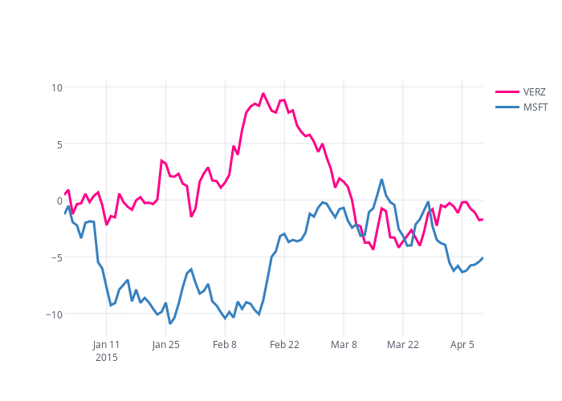

```python
df[['VERZ','MSFT']].iplot(filename='Tutorial Image',theme='white',colors=['pink','blue'],asImage=True,dimensions=(800,500),world_readable=True)
```

### Advanced Use

It is also possible to get the Plotly Figure as an output to tweak it manually

We can achieve this with **asFigure=True**

```python
df['GOOG'].iplot(asFigure=True)
```

```
{'data': [{'line': {'color': 'rgba(255, 153, 51, 1.0)', 'width': 3},
   'name': 'Series1',
   'type': 'scatter',
   'x': ['2015-01-01',
    '2015-01-02',
    '2015-01-03',
    '2015-01-04',
    '2015-01-05',
    '2015-01-06',
    '2015-01-07',
    '2015-01-08',
    '2015-01-09',
    '2015-01-10',
    '2015-01-11',
    '2015-01-12',
    '2015-01-13',
    '2015-01-14',
    '2015-01-15',
    '2015-01-16',
    '2015-01-17',
    '2015-01-18',
    '2015-01-19',
    '2015-01-20',
    '2015-01-21',
    '2015-01-22',
    '2015-01-23',
    '2015-01-24',
    '2015-01-25',
    '2015-01-26',
    '2015-01-27',
    '2015-01-28',
    '2015-01-29',
    '2015-01-30',
    '2015-01-31',
    '2015-02-01',
    '2015-02-02',
    '2015-02-03',
    '2015-02-04',
    '2015-02-05',
    '2015-02-06',
```

[output cut: 93 more lines]

```
            1.98956360e-01,  -1.00936898e+00,  -1.84083839e+00,
           -2.54320933e+00,  -4.76807123e+00,  -4.69514793e+00,
           -6.10458824e+00,  -7.65131832e+00,  -7.20910729e+00,
           -6.78737255e+00])}],
 'layout': {'legend': {'bgcolor': '#F5F6F9', 'font': {'color': '#4D5663'}},
  'paper_bgcolor': '#F5F6F9',
  'plot_bgcolor': '#F5F6F9',
  'xaxis': {'gridcolor': '#FFFFFF',
   'tickfont': {'color': '#4D5663'},
   'title': ''},
  'yaxis': {'gridcolor': '#FFFFFF',
   'tickfont': {'color': '#4D5663'},
   'title': '',
   'titlefont': {'color': '#4D5663'},
   'zeroline': False}}}
```

We can also get the **Data** object directly

```python
data=df.to_iplot()
```

```python
data[0]['name']='My Custom Name'
```

And pass this directly to **iplot**

```python
df.iplot(data=data,filename='Tutorial Custom Name',world_readable=True)
```

[interactive chart not shown]